# A3 - Neighborhood Score: Reloaded

Dhvani

October 6, 2017

### Problem Statement:

Implement neighborhood score using Hadoop and MapReduce:

1. Measure the performance on AWS running on 2 and 4 nodes
2. Return the median rather than the mean score of each word’s k-neighborhoods

### Implementation:

The entire program is divided into 3 major parts. Each part is run by a map reduce job.

1. In the first part, the mapper reads the input split and counts the number of occurrences of each character in the input. It then outputs each character as key and its occurrences as value. The reducer sums the value for each character and thus we get the output as a character and its total number of occurrences in the corpus.
2. In the second part, we override isSplitable method to false so that the input doesn’t split. In the mapper, we read line by line. It removes all characters except alphabets and space. We split the input with respect to space and thus have all the words in an array. Now we get neighbors of each word and output that. The reducer calculates the score for each word and then ouputs the word and its sum of neighborhood score for each file.
3. In the third and last part, the mapper takes input from the second reducer. It outputs the word as the key and its score as the value. The reducer then calculates the median. It sorts the values and calculates median. It then outputs the word as the key and the mean score as the value.

### Configuration of the machine used:

The program was run on AWS EMR. Below is the configuration of the machines used:

Master: vCPU: 8 RAM: 16GB Hard Disk: 100GB

Datanodes: vCPU: 16 RAM: 32GB Hard Disk: 100GB

### Result:

Below are the graphs for running the program with 2 and 4 nodes (big-corpus as the input). X-axis displays the jobs in the program i.e. job1 for the first map reduce job in the program and so on. Y-axis displays the time taken in minutes to complete map and reduce phase of each job.

The data is average of 2 iterations with k = 2.

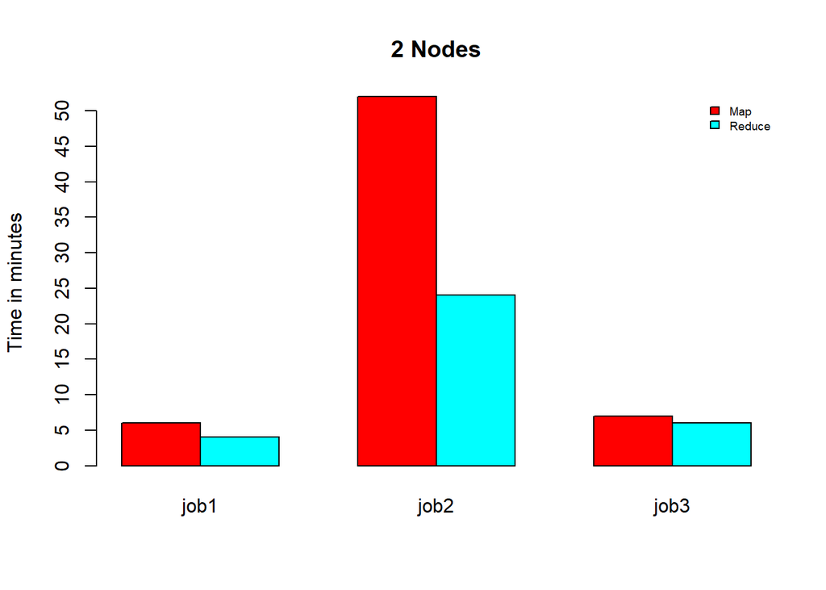

```r
results2 <- read.csv("report a3 2 nodes.csv", header = TRUE)

barplot(as.matrix(results2), main="2 Nodes", ylab= "Time in minutes",
   beside=TRUE, col=rainbow(2))

legend("topright", c("Map","Reduce"), cex=0.6,
   bty="n", fill=rainbow(2));

axis(side=2, at=c(5, 15, 25, 35, 45))
```

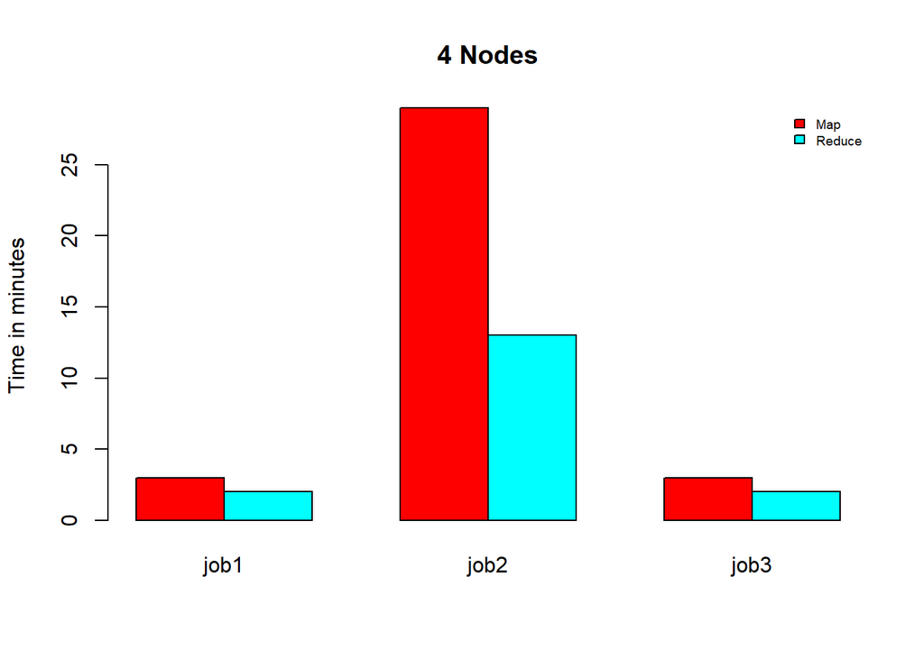

```r
results4 <- read.csv("report a3 4 nodes.csv", header = TRUE)

barplot(as.matrix(results4), main="4 Nodes", ylab= "Time in minutes",
   beside=TRUE, col=rainbow(2))

legend("topright", c("Map","Reduce"), cex=0.6,
   bty="n", fill=rainbow(2));
```